[figure not shown]

# Uso de Jupyter Notebooks en la docencia del máster de Ingeniería Informática

[figure not shown]

## Autores:

- Pedro González Yanes (Centro de Cálculo de ESIT)
- Carlos Pérez González (Departamento de Matemáticas, Estadística e Investigación Operativa)

# Contenidos de la presentación

- ¿Qué es Jupyter?
- Proyecto de innovación docente de la ESIT
- Funcionamiento y aspecto
  - ¿Cómo accede el usuario a su espacio de trabajo?
  - ¿Qué aspecto presenta el notebook de jupyter?
  - Algunos ejemplos ilustrativos (operaciones de cálculo y representación de gráficos)
- Utilización en el máster de Ingeniería Informática
- Conclusiones

# ¿Qué es Jupyter?

- El Jupyter Notebook es un entorno interactivo web que permite ejecutar código de ciertos programas:

R (statistical analysis)

Python (general purpose)

Julia (numerical computing)

Octave

- El alumno utiliza sólo un navegador (no es necesario instalar ningún programa) y puede introducir instrucciones a través de un cuaderno de trabajo (notebook) muy sencillo de manejar.
- Cada vez que se ejecuta una instrucción, ésta se procesa por el servidor y envía el resultado al notebook.
- El entorno permite que el alumno tenga un espacio de trabajo personal donde puede crear nuevos notebooks en los que trabajar y realizar las diferentes tareas .
- Al finalizar, el alumno puede descargar su notebook y enviarlo al profesor para su evaluación.

# Proyecto de innovación docente de la ESIT

[figure not shown]

- La dirección de la Escuela Superior de Ingeniería y Tecnología presentó este año el proyecto:
  - Implantación de la herramienta Jupyter e impulso del paradigma Open Notebook Science en el ámbito del Big Data y el Data Science
- El Centro de Cálculo de la Escuela instala una plataforma (jupyterhub) para el uso de los notebooks de Jupyter

[figure not shown]

- Tanto los profesores como alumnos pueden acceder cada uno a un espacio de trabajo donde crear y desarrollar las actividades con los notebooks

# Funcionamiento y aspecto

### ¿Cómo accede el usuario a su espacio de trabajo?

- El profesor y el alumno utilizan su usuario y password de ULL para entrar a su entorno personal de jupyter:

[figure not shown]

- El usuario puede configurar previamente un contenedor Docker con librerias y datos a usar:

[figure not shown]

- Y es en este entorno donde puede crear sus propios notebooks:

[figure not shown]

# Funcionamiento y aspecto

## ¿Qué aspecto presenta el notebook de jupyter?

- El notebook tiene el siguiente aspecto:

[figure not shown]

- Permite introducir código (operaciones de cálculo, gráficos, etc..), etiquetas, ecuaciones $\LaTeX$, ... así como descargar el notebook en múltiples formatos
- Los alumnos pueden editar y ejecutar en vivo el código
- Se puede crear una versión estática del notebook para que otros la puedan ver
- Tiene un enorme interés por lo que supone para la **Investigación reproducible**

## Ejemplo de operaciones de cálculo analítico

```python
%%latex
$$ \int_0^1 x  \exp(x)  \cos(x) dx $$
```

$$ \int_0^1 x \exp(x) \cos(x) dx $$

```python
import scipy.integrate as integrate
import scipy.special as special
from math import *
result = integrate.quad(lambda x: x * exp(x) * cos(x), 0, 1)
result
```

```
(0.7343469699579427, 8.152889141110261e-15)
```

```python
from sympy import *
x = symbols('x')
pprint(integrate(x * exp(x) * cos(x), x))
```

```
   x             x           x
x⋅ℯ ⋅sin(x)   x⋅ℯ ⋅cos(x)   ℯ ⋅sin(x)
─────────── + ─────────── - ─────────
     2             2            2
```

```python
f=integrate(x * exp(x) * cos(x), x)
f.evalf(subs={x:1})-f.evalf(subs={x:0})
```

```
0.734346969957943
```

## Ejemplo de representación de gráficos

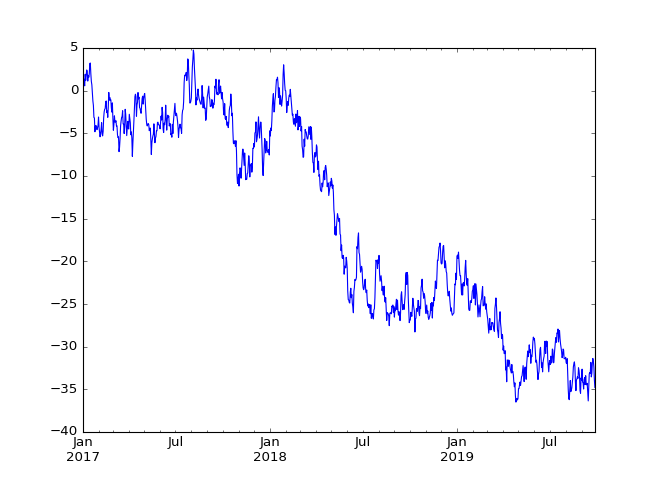

```python
%matplotlib notebook
import pandas as pd
import numpy as np
import matplotlib.pyplot as plt

ts = pd.Series(np.random.randn(1000),
               index=pd.date_range('01/01/2017', periods=1000))
ts = ts.cumsum()
ts.plot()
```

# Utilización en el máster de Ingeniería Informática

## Lab: Análisis de los gastos en tarjetas black de los directivos de Caja Madrid

[figure not shown]

- Se trata de aplicar técnicas estudiadas en clase para el análisis de datos masivos
- Los alumnos han de realizar una serie de ejercicios sobre los gastos realizados por los exdirectivos y consejeros de Caja Madrid utilizando tarjetas opacas
- El conjunto de datos sobre el que van a trabajar contiene información de los extractos de las tarjetas (información enviada por Bankia a la fiscalía y publicada en El País - http://elpais.com/especiales/2014/tarjetas-opacas-caja-madrid/)

### Question 1

Load data in fraude/movimientos_tarjetas_black_caja_madrid.csv

```python
from pyspark import SparkContext, SQLContext
sc =SparkContext()
sqlContext = SQLContext(sc)

def answer_one():
    df = sqlContext.read.format('com.databricks.spark.csv') \
                    .options(header='true', inferschema='true', delimiter=';') \
                    .load('file:///home/jovyan/work/Presentacion/fraude/movimientos_tarjetas_black_caja_madrid.csv')
    return df

df=answer_one()
df.printSchema()
```

```
root
 |-- id: integer (nullable = true)
 |-- nombre: string (nullable = true)
 |-- importe: double (nullable = true)
 |-- nombre_comercio: string (nullable = true)
 |-- actividad: string (nullable = true)
 |-- operacion: string (nullable = true)
 |-- fecha: timestamp (nullable = true)
 |-- fechayear: integer (nullable = true)
 |-- fechamonth: integer (nullable = true)
 |-- fechaday-of-month: integer (nullable = true)
 |-- fechaday-of-week: integer (nullable = true)
 |-- hora: string (nullable = true)
 |-- horahour: integer (nullable = true)
 |-- horaminute: integer (nullable = true)
 |-- horasecond: integer (nullable = true)
```

### Question 2

Obtain the 10 executives with the highest amount of expenses

```python
import pandas as pd
def answer_four():
    df_mapped=df.select('nombre','importe').rdd.map(lambda x: (x[0],x[1]))
    df_reduced=df_mapped.reduceByKey(lambda x,y:x+y)
    df_top=df_reduced.map(lambda x:(x[1],x[0])).sortByKey(ascending=False)
    return df_top

executives=answer_four()

executives=pd.DataFrame(executives.take(10), columns=["Gasto", "Ejecutivo"])
executives
```

|  | Gasto | Ejecutivo |
| --- | --- | --- |
| 0 | 572185.49 | SÁNCHEZ BARCOJ, ILDEFONSO JOSÉ |
| 1 | 447769.73 | MORAL SANTÍN, JOSÉ ANTONIO |
| 2 | 443999.19 | MORADO IGLESIAS, RICARDO |
| 3 | 429272.16 | AMAT ROCA, MATÍAS |
| 4 | 423068.49 | BLESA DE LA PARRA, MIGUEL |
| 5 | 389450.35 | FERRAZ RICARTE, RAMÓN |
| 6 | 354171.00 | PÉREZ CLAVER, MARIANO |
| 7 | 304818.36 | TORRE MARTÍNEZ, ENRIQUE DE LA |
| 8 | 287121.20 | ASTORQUI PORTERA, JUAN MANUEL |
| 9 | 284404.42 | DE LA MERCED MONGE, MARÍA MERCEDES |

```python
if executives['Gasto'][executives['Ejecutivo']=='BLESA DE LA PARRA, MIGUEL'].\
   to_string(index=False)=='423068.49':
    print('Correcto')
else:
    print('Incorrecto')
```

```
Correcto
```

### Question 3

Obtain the 10 persons who have expenses in businesses with the activity "CLUBS,SALAS FIESTA,PUBS,DISCOTECAS,BARES" and the total amount spent

```python
def answer_five():
    df_expenses = df.filter("actividad LIKE '%CLUBS%'"
                    or "actividad LIKE '%SALAS FIESTA%'"
                    or "actividad LIKE '%PUBS%'"
                    or "actividad LIKE '%SDISCOTECAS%'"
                    or "actividad LIKE '%BARES%'")
    df_expenses_mapped = df_expenses.rdd.map(lambda x: (x.nombre,x.importe))
    df_expenses_reduced = df_expenses_mapped.reduceByKey(lambda x,y:x+y)
    df_expenses_top=df_expenses_reduced.map(lambda x:(x[1], x[0])).sortByKey(ascending=False).take(10)

    return pd.DataFrame([ (x[1],x[0]) for x in df_expenses_top ] ,columns=['name','total_amount'])

persons=answer_five()
persons
```

|  | name | total_amount |
| --- | --- | --- |
| 0 | GABARDA DURÁN, LUIS | 9748.71 |
| 1 | DE NAVASQUES COBIÁN, IGNACIO | 4640.55 |
| 2 | MARTÍNEZ MARTÍNEZ, CARLOS MARÍA | 4207.95 |
| 3 | RECARTE GARCÍA ANDRADE, ALBERTO | 4028.40 |
| 4 | SÁNCHEZ BARCOJ, ILDEFONSO JOSÉ | 3561.06 |
| 5 | SPOTTORNO DÍAZ CARO, RAFAEL | 3355.90 |
| 6 | AZCONA OLONDRIZ, JUAN JOSÉ | 3345.21 |
| 7 | BUENAVENTURA ZABALA, JOSÉ MARÍA | 2516.41 |
| 8 | RATO FIGAREDO, RODRIGO DE | 2305.16 |
| 9 | AMAT ROCA, MATÍAS | 1676.93 |

### Question 4

Using pandas, represent in a chart the evolution for years in the expenses of Rodrigo Rato

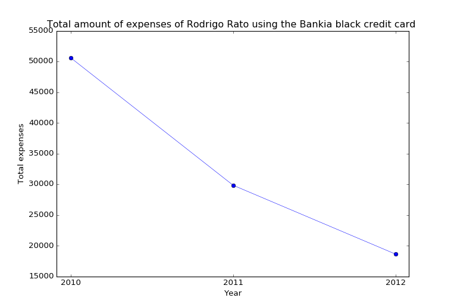

```python
%matplotlib notebook
import matplotlib.pyplot as plt
import numpy as np
from datetime import date, datetime
import matplotlib.dates as dates

rodrigoExpenses = df.filter("nombre LIKE '%RATO%'")
mappedYearlyExpenses = rodrigoExpenses.rdd.map(lambda x: (x.fechayear,x.importe))
reducedYearlyExpenses = mappedYearlyExpenses.reduceByKey(lambda x,y:x+y)

orderedReducedYearlyExpenses = reducedYearlyExpenses.sortBy(lambda x: x[0])
resultDF = orderedReducedYearlyExpenses.toDF(['year', 'expenses'])

plotres1(resultDF)
```

### Question 5

Using pandas, represent the top 5 activities of the business where Rodrigo Rato spent most.

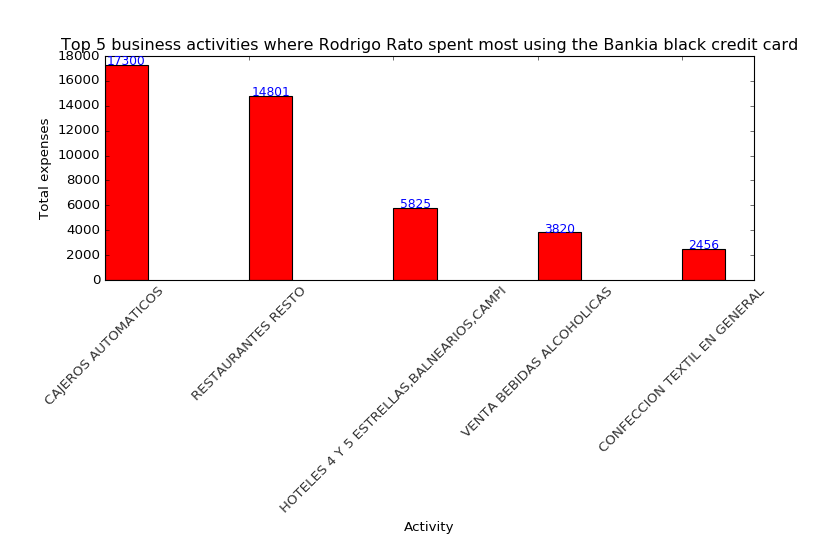

```python
mappedActivityExpenses = rodrigoExpenses.rdd.map(lambda x: (x.actividad,x.importe))
reducedActivityExpenses = mappedActivityExpenses.reduceByKey(lambda x,y:x+y)

orderedReducedActivityExpenses = reducedActivityExpenses.sortBy(lambda x: x[1], False)
orderedReducedActivityExpensesDF = orderedReducedActivityExpenses.toDF(['activity', 'expense'])

result = orderedReducedActivityExpensesDF.toPandas().head(5)


plotres2(result)
```

# Conclusiones

- Jupyter representa una herramienta de trabajo con grandes posibilidades para el desarrollo de actividades
- Esta presentación se ha realizado también con un notebook de Jupyter (slideshow)
- Hay un gran número de librerías en Python que se pueden utilizar a través de este entorno (de física, biología, genómica, etc..)
- Los gráficos interactivos no son muy complicados de generar y eso permite crear tutoriales, prácticas guiadas, etc...

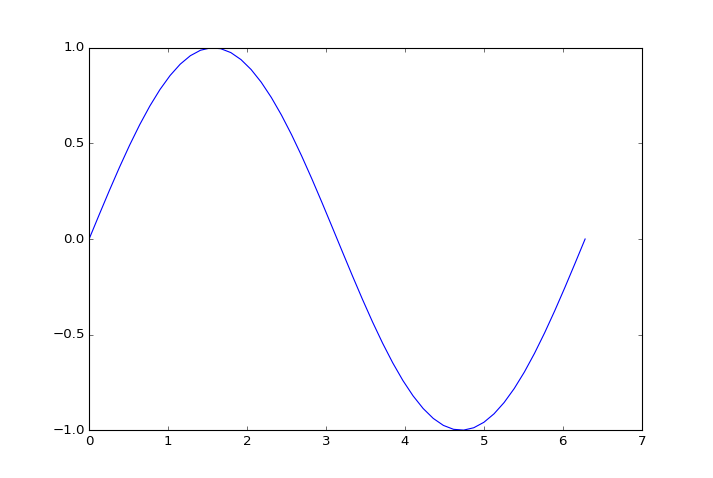

```python
from ipywidgets import *
import numpy as np
import matplotlib.pyplot as plt
%matplotlib notebook

x = np.linspace(0, 2 * np.pi)

def update(w = 1.0):
    fig = plt.figure()
    ax = fig.add_subplot(1, 1, 1)
    ax.plot(x, np.sin(w * x))

    fig.canvas.draw()

interact(update);
```